# AQM Week 10 – Conditional Multinomial Choice Models

Oliver Rittmann

Domantas Undzėnas

May 4, 2023

```r
# The first line sets an option for the final document that can be produced from
# the .Rmd file. Don't worry about it.
knitr::opts_chunk$set(echo = TRUE)

# First you define which packages you need for your analysis and assign it to
# the p_needed object.
p_needed <-
  c("viridis", "knitr", "MASS", "pROC", "nnet", "mlogit")

# Now you check which packages are already installed on your computer.
# The function installed.packages() returns a vector with all the installed
# packages.
packages <- rownames(installed.packages())
# Then you check which of the packages you need are not installed on your
# computer yet. Essentially you compare the vector p_needed with the vector
# packages. The result of this comparison is assigned to p_to_install.
p_to_install <- p_needed[!(p_needed %in% packages)]
# If at least one element is in p_to_install you then install those missing
# packages.
if (length(p_to_install) > 0) {
  install.packages(p_to_install)
}
# Now that all packages are installed on the computer, you can load them for
# this project. Additionally the expression returns whether the packages were
# successfully loaded.
sapply(p_needed, require, character.only = TRUE)
```

```
viridis   knitr    MASS    pROC    nnet  mlogit
   TRUE    TRUE    TRUE    TRUE    TRUE    TRUE
```

## Where are we on the AQM road?

- **Session 1 to 5**: The fundamental prerequisites:
  - OLS Recap
  - Matrix Algebra
  - Intro to Maximum Likelihood Estimation
- **Session 6 to 10**: Models for…
  - …binary dependent variables (session 6 and 7)
  - …ordinal dependent variables (session 8)
- …categorical dependent variables (session 9 and 10)
  - Next week in the lecture (and hw06): Models for…
  - …truncated or censored dependent variables

In the remaining weeks:

- **Session 11 to 12**: Sneak peek into more advanced models:
  - Multi-level models
  - Bayesian Analysis

The next two weeks in the tutorial: + Clarification of + “fixed” and “random” effects + Multi-Level data structures and Multi-level models

## Program for today

In this session, we will learn about:

1. Multinomial Choice Models:
   - Leftovers from last week: OVA Simulation over a range of values.
2. Conditional Multinomial Choice Models.

## Multinomial Choice Leftovers

We start with the essential code from last week

```r
# Load data
load("raw-data/Nethvote.RData")
df <- Nethvote

# Likelihood function
ll_mnl <- function(theta, X, Z) {
  # declarations
  k <- ncol(X) # k independent variables
  J <- ncol(Z) # J choices in the dependent variable

  # create matrix of betas and set the first category to 0
  beta <- matrix(0,
                 ncol = k,
                 nrow = J)
  beta[-1, ] <- matrix(theta[1:(k * (J - 1))],
                       ncol = k,
                       byrow = T)

  # Systematic component: utilities
  # X_i %*% beta_J in each row (i.e. for each available choice)
  V <- apply(beta, 1,
             function(b)
               X %*% b)

  # Sum of exp(V)
  Sexp <- apply(V, 1, function(v)
    sum(exp(v)))

  # probabilities
  P <- apply(V, 2, function(v)
    exp(v) / Sexp)

  # log-likelihood
  loglik <- sum(log(P[Z]))
  return(loglik)
}

# Data preperation
cats <- sort(unique(df$vote))  # different categories
J <- length(unique(df$vote))  # number of categories

Z <- matrix(NA,
            nrow = length(df$vote),
            ncol = J)  # indicator matrix

for (j in 1:J) {
  Z[, j] <- df$vote == cats[j]
}
colnames(Z) <- cats

X <- as.matrix(cbind(1, df[, 6:11]))

# Model estimation
startvals <- rep(0, ncol(X) * (J - 1))

res <- optim(
  startvals,
  ll_mnl,
  X = X,
  Z = Z,
  method = "BFGS",
  control = list(fnscale = -1, trace = TRUE),
  hessian = TRUE
)
```

### Exercise: The observed value approach for a range of values

Simulate predicted probabilities and the surrounding uncertainty using the observed value approach to visualize the **effect of income** (eg. a range of 10 values of income – don’t use more, ten will already take a little while to compute).

```r
# Set-up and draw from multivariate normal
mu <- res$par
varcov <- solve(-res$hessian)

# Define nsim, J (number of categories) and k (number of independent variables)
nsim <- 1000
J <- length(unique(df$vote))  # Number of categories
k <- ncol(X)

# Set up the sampling distribution
S <- mvrnorm(nsim, mu, varcov)

# Store in an array similar to what we did in the ll function
beta_S <- array(0, dim = c(J, k, nsim))

# fill the array with the sampling distribution of betas
for(sim in 1:nsim) {
  beta_S[-1, ,sim] <- matrix(S[sim,],
                             ncol = k,
                             byrow = T)
}

# start with the scenario (the steps before are the same)
sel <- which(colnames(X) == "income")

incomeScenario <- quantile(X[, sel], seq(0, 1, length.out = 10))

n_scenarios <- length(incomeScenario)

cases <- array(NA, dim = c(dim(X),
                           n_scenarios))

cases[, , ] <- X

for (i in 1:n_scenarios) {
  cases[, sel, i] <- incomeScenario[i]
}

# Calculate the utilities V (Systematic component!)
V <- array(NA,
           dim = c(nrow(X),       # number of observations
                   J,             # number of categories
                   nsim,          # number of simulations
                   n_scenarios))  # number of scenarios

# Loop over the scenarios
for(i in 1:n_scenarios){
  V[,,,i] <- apply(beta_S[,,], c(1,3),
                   function(bs) cases[,,i] %*% bs)
}
```

We now have the utilities $V_{ij}$. Next, we want to use this in order to get probabilities. In other words: We want to apply the **link function**:

$$P(y_i=j) = \frac{exp[V_{ij}]}{\sum
exp[V_{ik}]}$$

```r
# Now we want to summarize over multiple dimensions (calculate Sexp)
Sexp <- apply(V, c(1,3,4), function(v) sum(exp(v)))

# With V and Sexp we have everything to get P
P <- array(NA, c(nsim, J, n_scenarios))

for (scen in 1:n_scenarios) {
  for (category in 1:J) {
    P[, category, scen] <-
      apply(exp(V[, category, , scen]) / Sexp[, , scen], 2, mean)
  }
}

# Summarize to get our quantities of interest

# solution 1: with apply
QoImean <- apply(P, c(2, 3), mean)
QoICI <-
  apply(P, c(2, 3), function(x)
    quantile(x, probs = c(0.025, 0.975)))

# solution 2: with a loop
QoImean <- matrix(NA, nrow = 4, ncol = n_scenarios)
QoICI <- array(NA, dim = c(2,     # lower and upper bound
                           4,     # number of categories
                           10))   # number of scenarios


for (i in 1:n_scenarios) {
  QoImean[,i] <- apply(P[, , i], 2, mean)
  QoICI[,,i] <- apply(P[, , i], 2, function(x)
    quantile(x, probs = c(0.025, 0.975)))

}
```

```r
partycolors <- c("mediumseagreen",
                 "green",
                 "red",
                 "orange")

# if you did everything correctly, you can plot your results
plot(
  incomeScenario,
  QoImean[1,],
  type = "n",
  ylim = c(0, 0.65),
  bty = "n",
  ylab = "Predicted Probability of voting for Party",
  xlab = "income Variable",
  main = "The Effect of Income",
  las = 1
)

for (i in 1:4) {
  polygon(
    c(rev(incomeScenario), incomeScenario),
    c(rev(QoICI[1, i,]), QoICI[2, i,]),
    col = adjustcolor(partycolors[i], alpha = 0.2),
    border = NA
  )
}
```

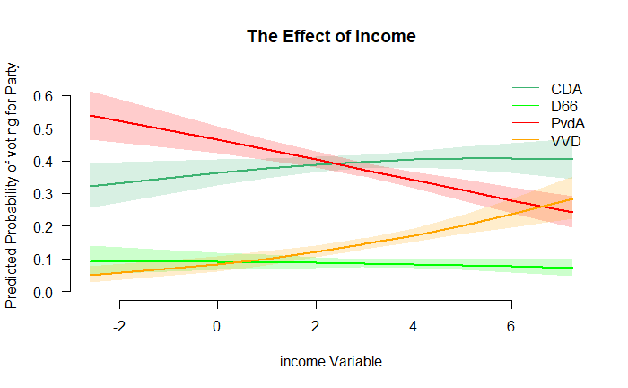

```r
for (i in 1:4) {
  lines(x = incomeScenario,
        y = QoImean[i,],
        col = partycolors[i],
        lwd = 2)
}

legend(
  "topright",
  legend = levels(df$vote),
  lty = 1,
  col = partycolors,
  bty = "n"
)
```

## Conditional Logit

In the last session we looked at the multinomial logit that dealt with unordered choices (multinomial choices) where our predictor variables were **chooser-specific**. However, in principle, predictor variables could vary over choices only (and be constant over individuals a.k.a. **choice-specific**), vary over choices and individuals (**chooser- AND choice-specific**), or – as seen in the last session – vary only over individuals.

- **chooser-specific**: Variables that vary across individuals
  - income
  - education
  - religion
  - left-right position of the respondent
  - …
- **choice-specific**: Variables that vary across choices
  - party family
  - left-right position of the party
- **chooser- and choice-specific**: Variables that vary across individuals and choices
  - e.g. distance between respondent and party left-right position

The multinomial choice model we looked at last week allowed us to include chooser-specific variables.

The **conditional logit model** is appropriate for multinomial choice data **when predictors vary over choices or choices and individuals**. Even more general, such models allow for all kinds of predictor variables at the same time.

Let’s look at the multinomial choice model from the last session and see how we can extend it to get a conditional choice model. The systematic component of the utility for the multinomial choice model is:

$$V_{ij} = X_i\beta_j$$

The probability that individual $i$ chooses choice $j$ is:

$$\text{Pr}(y_i = j) = \frac{\exp(\mathbf{X}_{i}{\beta_j})}{\sum_{j=0}^J
\exp(\mathbf{X}_{i}{\beta_j)}}$$
Note that $X_i$ contains only chooser specific variables. In many applications – also in the one we are going to take a closer look at today – we would want to estimate a model that also includes variables that vary over individuals **and** choices. To achieve this, we can write the systematic component like this:

$$V_{ij} = \mathbf{X}_{i}\beta_j + \mathbf{W}_{ij}{\gamma}$$

Like last week, let’s focus on the indexation for a moment:

- $i$ indicates individual observations, in our case voters.
- $j$ indicates choices of the outcome variable, in our case vote choices for different parties.

With this in mind, let’s see what we have here:

- $V_{ij}$: For each voter $i$, this formula computes utilities of voting for all parties $j$. This is the utility of voter $i$ to vote for the CDA, D66, PcdA, and VVD.
- $X_i$: This is nothing new, just our matrix of covariates, i.e. information on income, class, religion, and so on for each voter $i$.
- $\beta_j$: $\beta$ is indexed by $j$. $j$ are the available choices. This means that we have one $\beta$ vector for each outcome choice.
- $W_{ij}$: A second matrix of covariates (like $X_i$), but this time subscripted with $i$ and $j$. Thus, $W_{ij}$ stores covariates that vary across individuals **and** choices (for example the left-right distance between a voter and a party.
- $\gamma$ has no subscript at all. Consequentially, it does not vary between choices, there is only one $\gamma$ vector! Why? Left-right distance should affect the utilities to vote for specific parties in the same way.

$$\text{Pr}(y_i = j) = \frac{\exp(\mathbf{X}_{i}{\beta_j} +
\mathbf{W}_{ij}{\gamma})}{\sum_{j=1}^J \exp(\mathbf{X}_{i}{\beta_j} +
\mathbf{W}_{ij}{\gamma})}$$

One more time: In this model, the effects $\beta_j$ of **chooser-specific** variables vary across the alternatives while $\gamma$ does not.

## Getting it into `R`

We start with a specific example and then generalize the function. Our working example is a simple **spatial proximity model**: The central hypothesis of this theoretical model reads as follows:

> The smaller the ideological distance between the respondent and a candidate or party, the higher the probability that the respondent votes for the candidate or party.

We would like to test this hypothesis. So the systematic part of the model we want to estimate is:

$$V_{ij} = \beta_j + \gamma \times \text{Distance}_j$$
**Note**: No chooser-specific covariate matrix $X$. Thus, $\beta_j$ only conatains choice-specific intercepts.

We will work with the same data as last week.

```r
head(df)
```

|  | vote | distD66 | distPvdA | distVVD | distCDA | relig | class | income | educ | age | urban |
| --- | --- | --- | --- | --- | --- | --- | --- | --- | --- | --- | --- |
| 1 | PvdA | 2.66969500 | 2.3351206 | 4.10988070 | 6.4500795 | 0 | 0 | 1 | 2 | 5 | 1 |
| 2 | CDA | 0.08812697 | 0.1497518 | 0.21012678 | 2.2491909 | 1 | 2 | 0 | 2 | 3 | 0 |
| 3 | CDA | 6.34689760 | 6.5365987 | 4.95243360 | 1.6800155 | 1 | 2 | 0 | 2 | 1 | 0 |
| 4 | D66 | 6.37209390 | 6.8225008 | 6.08275170 | 12.0449310 | 0 | 2 | 0 | 2 | 1 | 0 |
| 5 | VVD | 0.28401647 | 0.3925463 | 0.02252145 | 0.9383029 | 1 | 2 | 0 | 2 | 1 | 0 |
| 6 | D66 | 0.12552651 | 0.2234177 | 0.06179921 | 1.7621459 | 0 | 2 | 0 | 2 | 0 | 0 |

```r
table(df$vote)
```

```
 CDA  D66 PvdA  VVD
 679  143  663  269
```

The variables we are mainly interested in today are the ideological distances between each respondent and each party. Clearly, these variables are individual and party specific (**chooser and choice-specific**). So we need to change the systematic component of our multinomial logit model from last week. For reference, here is last week’s function that allowed for choose specific variables:

```r
ll_mnl <- function(theta, X, Z) {
  # declarations
  k <- ncol(X)
  J <- ncol(Z)

  # create matrix of betas and set the first category to 0
  beta <- matrix(0,
                 ncol = k,
                 nrow = J)
  beta[-1, ] <- matrix(theta[1:(k * (J - 1))],
                       ncol = k,
                       byrow = T)

  # utilities, systematic part
  V <- apply(beta, 1, function(b)
    X %*% b)

  # Sum of exp(V)
  Sexp <- apply(V, 1, function(v)
    sum(exp(v)))

  # probabilities
  P <- apply(V, 2, function(v)
    exp(v) / Sexp)

  # log-likelihood
  loglik <- sum(log(P[Z]))
  return(loglik)
}
```